# Lecture 6: Graphics with R

- Graphical functions & parameters
- Multiple plots on one page
- Save a plot

There are different packages in R that suit all kinds of plotting needs people may have.

- **graphics**
  - In base R and loads automatically every time you open R
  - The R Graphics Package
- **grid**
  - In base R but does not load automatically
  - The Grid Graphics Package
- **ggplot2**
  - Not in base R
  - Create Elegant Data Visualisations Using the Grammar of Graphics
  - Depends on grid
- ...

Today we use the **graphics** package to draw various 2D plots.

https://stat.ethz.ch/R-manual/R-devel/library/graphics/html/00Index.html

```r
# Survey result with all personal information deleted
d <- read.csv("https://raw.githubusercontent.com/ly129/EPIB613/master/survey")
head(d)
```

| X | agree_exams | agree_groups | agree_handson | agree_comp | mathcomf | coffee | screentime |
| --- | --- | --- | --- | --- | --- | --- | --- |
| 1 | Disagree | Strongly agree | Agree | Neutral | 4 | 2 | 6 |
| 2 | Disagree | Neutral | Neutral | Neutral | 4 | 1 | 5 |
| 3 | Disagree | Strongly agree | Strongly agree | Neutral | 2 | 0 | 5 |
| 4 | Disagree | Agree | Strongly agree | Agree | 3 | 0 | 5 |
| 5 | Disagree | Disagree | Strongly agree | Neutral | 3 | 0 | 20 |
| 6 | Disagree | Neutral | Neutral | Disagree | 4 | 1 | 16 |

# 6.1 Graphical functions & parameters

### Functions:

#### New plot

- plot( )
- pie( )
- boxplot( )
- hist( )
- curve( )
- ...

#### Add to existing plot

- lines( )
- points( )
- abline( )
- legend( )
- axis( )
- ...

### Parameters

Parameters are used to customize your plots. I will show the use of some parameters here and there in the lecture.

There are many so you will not see all the parameters here. Check out the link below or google when you need to plot something fancy.

https://stat.ethz.ch/R-manual/R-devel/library/graphics/html/par.html

Different parameters are allowed in different functions. Parameters can also be specified before plotting using **par( )**.

## 6.1.1 Scatter plot

###### Coffee consumption vs. screen time

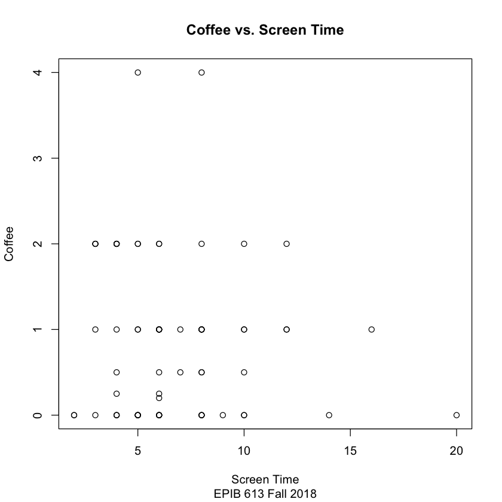

```r
plot(x = d$screentime, y = d$coffee,
     main = "Coffee vs. Screen Time",    # Title
     sub = "EPIB 613 Fall 2018", # Sub title
     xlim =,                     # limits of x-axis
     ylim =,                     # Limits of y-axis
     xlab = "Screen Time",       # Label of x-axis
     ylab = "Coffee",            # Label of y-axis
     log = ""                    # Axis to be set on log scale
)
# x and y are arguments - these two are sufficient for a plot
# In this plot, I specified some most basic graphical parameters.
```

##### Suppose the screentime comes from a single person and we want to see the trend.

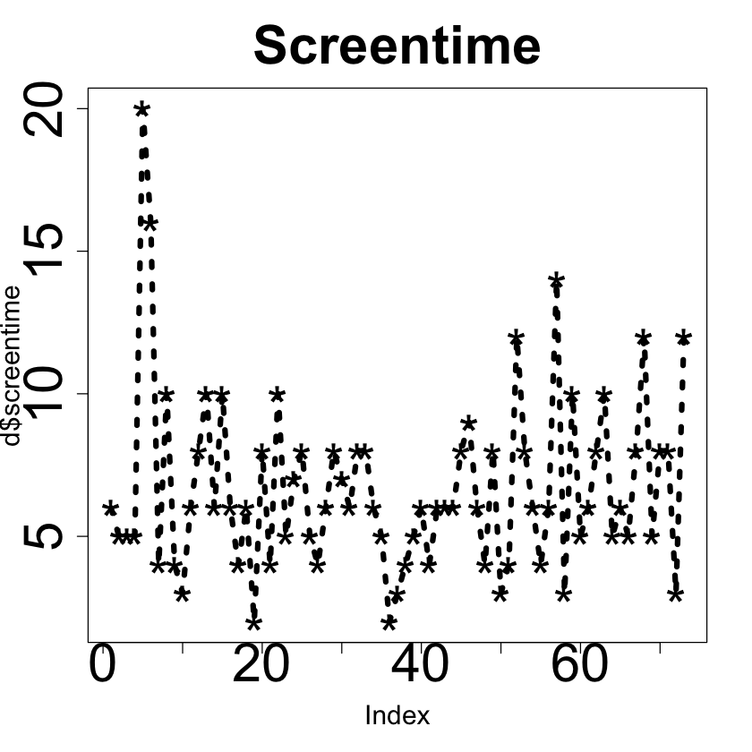

```r
# Some parameters related to text and plot size.
plot(d$screentime,
     type = "o",    # Type of plot, default is points.
     pch = "*",     # plotting symbols, 1~25 plus anything you want.
     cex = 3,       # Plotting text and symbol size
     cex.axis = 3,  # Axis annotation size
     main = "Screentime",
     cex.main = 3,  # Title text size
     cex.lab = 1.5, # Axis label size
     lwd = 5,       # Line width
     lty = 3
)
```

## 6.1.2 Pie plot

```r
table(d$agree_exams)
```

```
            Agree          Disagree           Neutral Strongly disagree
               10                27                32                 4
```

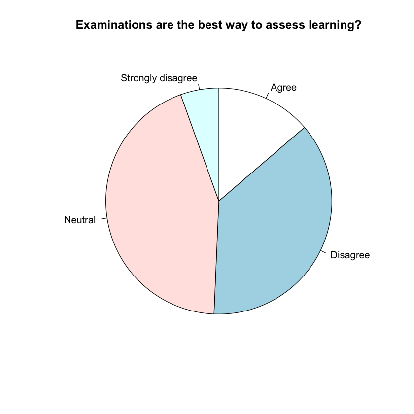

```r
# My first pie chart......
pie(x = table(d$agree_exams),
    col =,
    clockwise = TRUE,
    main = "Examinations are the best way to assess learning?",
)
```

## 6.1.3 Histogram

##### hist(x) requires that the x is numeric.

##### Consider barplot(x) and plot(x, type = "h") if x is not numeric.

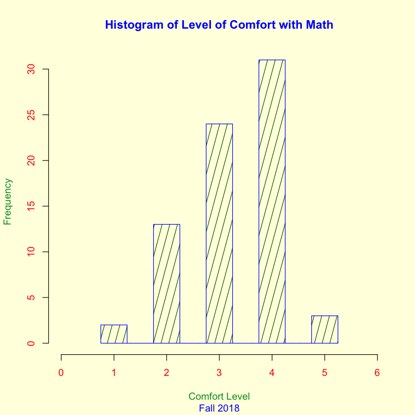

```r
par(bg = "lightyellow") # par() sets graphical parameters before plots.
hist(d$mathcomf,
     breaks = seq(0.75, 5.25, 0.5),   # Without this, the histogram is ugly.
     xlim = c(0, 6),
     main = "Histogram of Level of Comfort with Math",
     sub = "Fall 2018",
     xlab = "Comfort Level",
     col.main = "blue",
     col.axis = 2,
     col.lab = "#009933",
     col.sub = 4,           # multiple ways to specify color.
     col = "darkgreen",
     border = "blue",       # Color of border of the bars
     density = 8,           # density of shading lines
     angle = 75             # angle of shading lines, in degrees.
)
# border, density and angle are parameters specific to hist().
# Mostly showed parameters related to colors.
# Sorry I am really really really bad with colors.
```

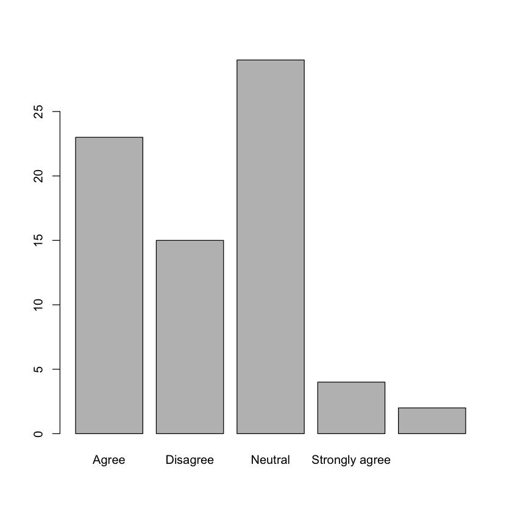

```r
barplot(table(d$agree_comp))
```

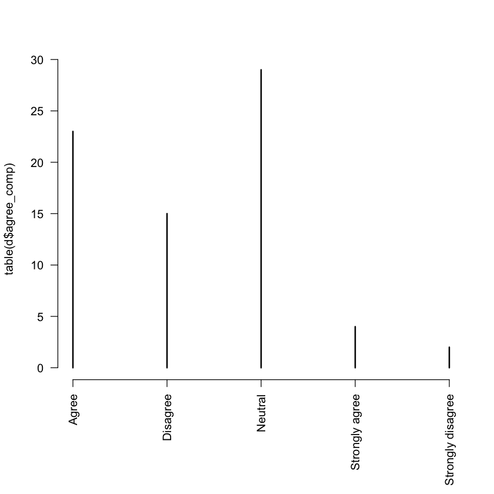

```r
par(mar = c(8, 4, 4, 2) + 0.1)
# Set the margins around the plotting area
plot(table(d$agree_comp), type = "h", las = 2)
# las controls the orientation of axis annotations.
```

## 6.1.5 Boxplot

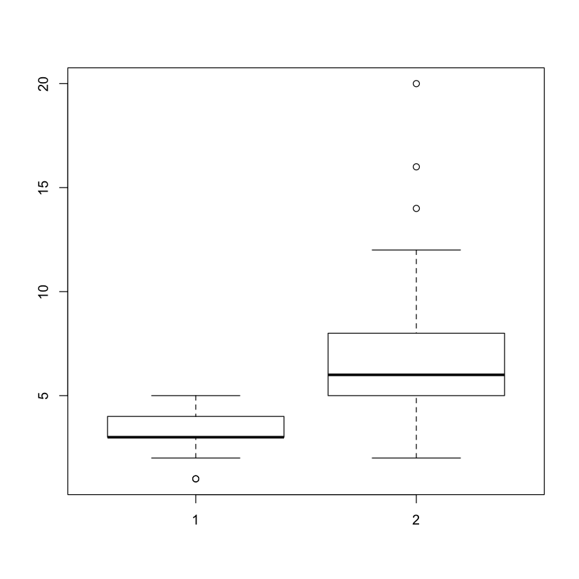

```r
boxplot(d$mathcomf, d$screentime)
```

## 6.1.6 Draw functions

[figure not shown]

```r
fx1 <- function(x){x^2-10}
fx2 <- function(x){x^3}
curve(fx1,
      xlim = c(-10, 10), ylim = c(-10, 10),
      col = 2, lty = 1)
curve(fx2, add = TRUE,   # add is an parameter in curve()
      col = 3, lty = 2)  # TRUE -> plot on the existing plot

x <- seq(from = -10, to = 2, by = 0.25)
y <- exp(x)
points(x=x, y=y, pch = ">")  # Add these points to the existing plot
# Add the smooth line containing these points to the existing plot
# lines(x=x, y=y)

abline(h = 5, lty = 3)      # h -> horizontal line at y = 5
abline(v = -8, lty = "dotdash")     # v => vertical line at x = -8

abline(a = 0, b = 1/2)      # y = a + bx

legend(x = 5, y = -7,       # Can also be "top", "bottomright", ...
       c(expression(paste(x^2-10)), expression(paste(x^3))),
       col = c(2,3,1),      # Usually corresponds to the plot
       lty = c(1,2),
       text.col = c(2,3))
```

##### Draw density functions

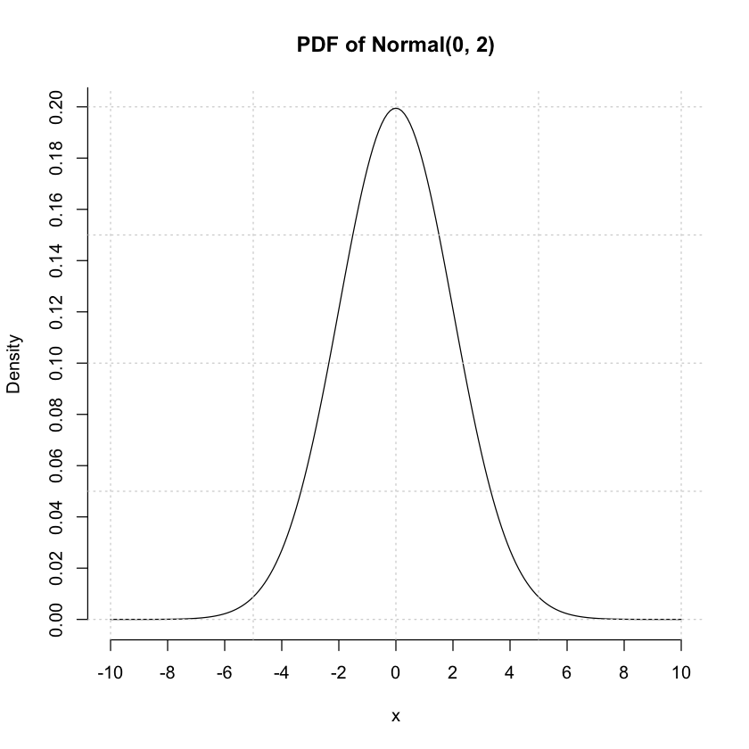

```r
xx <- seq(from = -10, to = 10, by = 0.1)
yy <- dnorm(xx, mean = 0, sd = 2)
# dnorm() gives the normal distribution density
plot(x = xx, y = yy, type = "l", main = "PDF of Normal(0, 2)",
     axes = F,      # Suppress axes
     xlab = "x", ylab = "Density"
)
axis(1, at = seq(from = -10, to = 10, by = 2))
axis(2, at = seq(from = 0, to = 1, by = 0.02))
grid()   # add grid lines.
# Explore the parameters allowed in grid()
```

## 6.2 Multiple plots on one page

```
    - par(mfrow = )
    - layout()
```

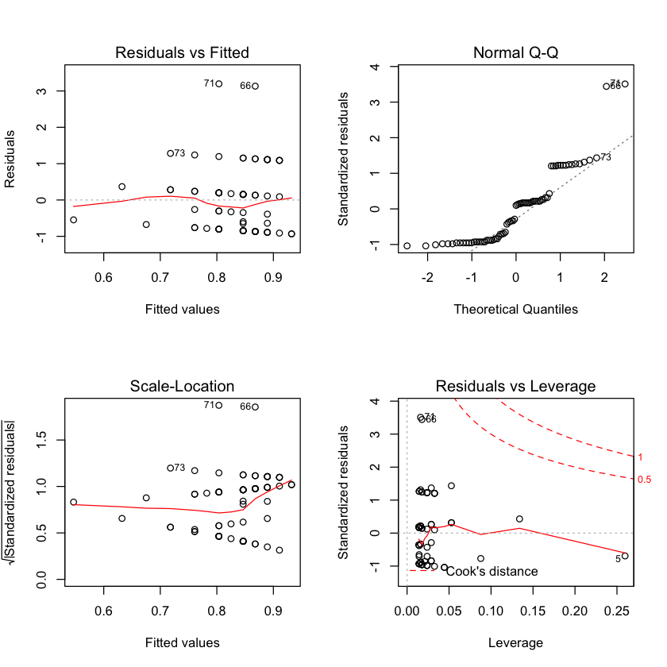

```r
par(mfrow = c(2, 2)) # 2 x 2 = 4 plots on the same page
plot(lm(coffee~screentime, data = d))
# lm() for linear regression - EPIB 621 material
# Plot your linear regression object will give 4 diagnostic plots.
```

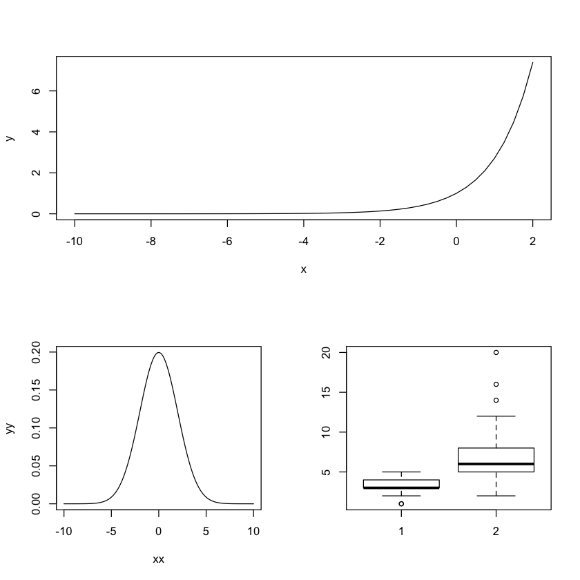

```r
nf <- layout(matrix(c(1,1,2,3), 2, 2, byrow = TRUE))
# layout.show(nf)  # Shows the partition of the plotting area
plot(x=x, y=y, type = "l")
plot(x=xx, y=yy, type = "l")
boxplot(d$mathcomf, d$screentime)
```

## 6.3 Save a plot

```r
pdf(file = "Normal_Density.pdf")
plot(x = xx, y = yy, type = "l", main = "PDF of Normal(0, 2)",
     axes = F, xlab = "x", ylab = "Density")
axis(1, at = seq(from = -10, to = 10, by = 2))
axis(2, at = seq(from = 0, to = 1, by = 0.02))
grid()
dev.off()
```

**pdf:** 2

## Exercise for bonus points!

Use a for loop, draw and save density plots of Normal(0,1), Normal(1,2), Normal(2,3), Normal(3,4) and Normal(4,5) in pdf format.

Requirements:

- The plots should have the same axis limits and labels.
- The title of the plots should be Normal(0,1), Normal(1,2), Normal(2,3), Normal(3,4) and Normal(4,5).
- The plots should have different background colors.
- The density plots should have different line types - solid, dashed...
- Any customization that you think will make your plots look better.

```r
mu <- 0:4
sigma <- 1:5
bg.color <- c("", "", "", "", "") # Colors of your choice
```